# Temperature size rule results

### Background

```r
data3 <- read_csv("/Users/Joey/Documents/Daph-TSR/data-processed/data3.csv")
```

### Reproductive rate

How does reproductive rate vary with temperature?

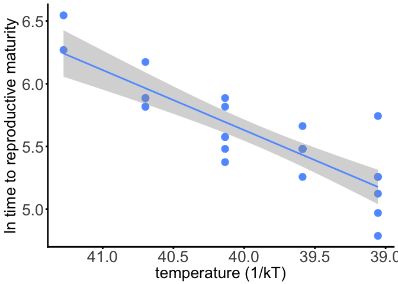

```r
data3 %>%
    filter(unique_id != "K_16") %>% ## something weird is going on here!
    mutate(inverse_temp = (1/(.00008617*(temperature+273.15)))) %>%
    do(tidy(lm(log(time_to_first_clutch) ~ inverse_temp, data = .), conf.int = TRUE)) %>%
    knitr::kable(.)
```

| term | estimate | std.error | statistic | p.value | conf.low | conf.high |
| --- | --- | --- | --- | --- | --- | --- |
| (Intercept) | -13.5224258 | 2.3825210 | -5.67568 | 7.6e-06 | -18.4397074 | -8.6051442 |
| inverse_temp | 0.4788195 | 0.0596525 | 8.02681 | 0.0e+00 | 0.3557027 | 0.6019362 |

Time between clutches

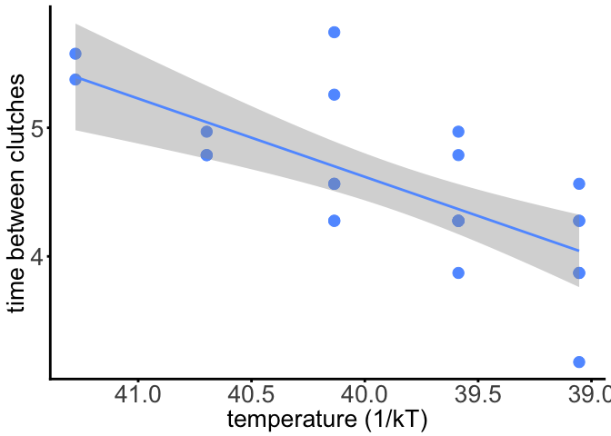

```r
## time between clutches
data3 %>%
    filter(unique_id != "K_16") %>% ## something weird is going on here!
    mutate(inverse_temp = (1/(.00008617*(temperature+273.15)))) %>%
    do(tidy(lm(log(time_btw_1_2) ~ inverse_temp, data = .), conf.int = TRUE)) %>%
    knitr::kable(.)
```

| term | estimate | std.error | statistic | p.value | conf.low | conf.high |
| --- | --- | --- | --- | --- | --- | --- |
| (Intercept) | -19.7276177 | 5.1098596 | -3.860697 | 0.0008466 | -30.3248179 | -9.1304174 |
| inverse_temp | 0.6086533 | 0.1281431 | 4.749792 | 0.0000967 | 0.3429007 | 0.8744058 |

### Body size

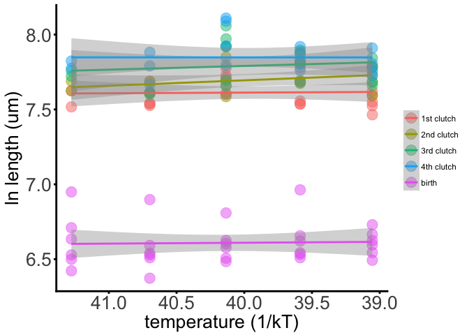

### Somatic growth rates

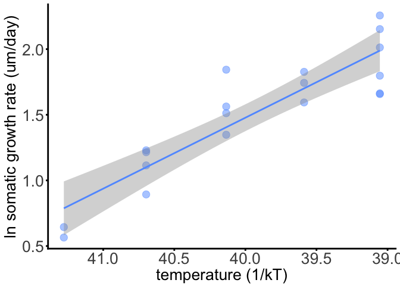

```r
data3 %>%
    filter(unique_id != "K_16") %>% ## something weird is going on here!
    mutate(inverse_temp = (-1/(.00008617*(temperature+273.15)))) %>%
    mutate(somatic_growth_rate = ((length_at_1st_clutch - length_at_birth_um)/time_to_first_clutch)) %>%
do(tidy(lm(log(somatic_growth_rate) ~ inverse_temp, data = .), conf.int = TRUE)) %>%
    knitr::kable(.)
```

| term | estimate | std.error | statistic | p.value | conf.low | conf.high |
| --- | --- | --- | --- | --- | --- | --- |
| (Intercept) | 23.0958538 | 2.5278438 | 9.136583 | 1e-07 | 17.7625697 | 28.4291380 |
| inverse_temp | 0.5404576 | 0.0632702 | 8.542051 | 1e-07 | 0.4069691 | 0.6739461 |

### Size rate trade-off??

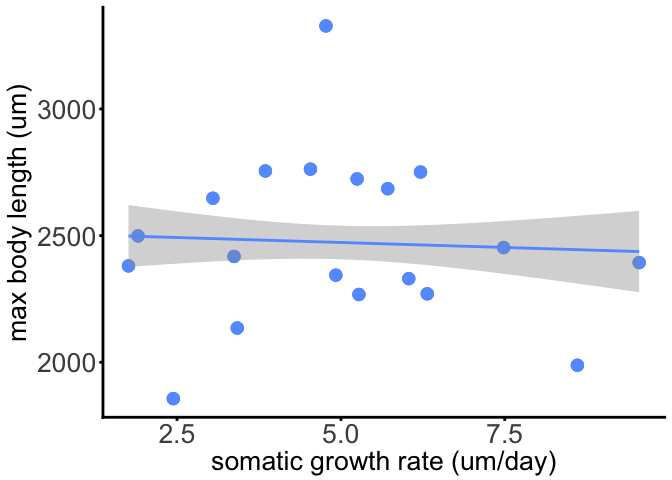

#### Body size over time

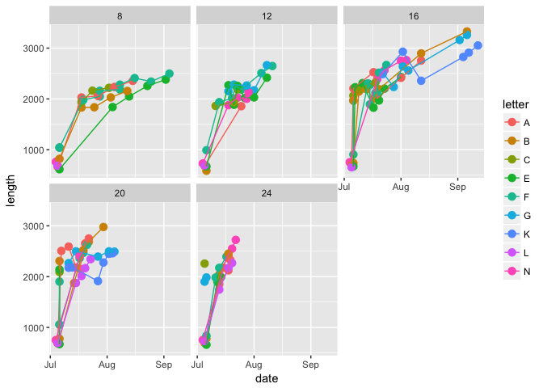

#### Minimum adult body size

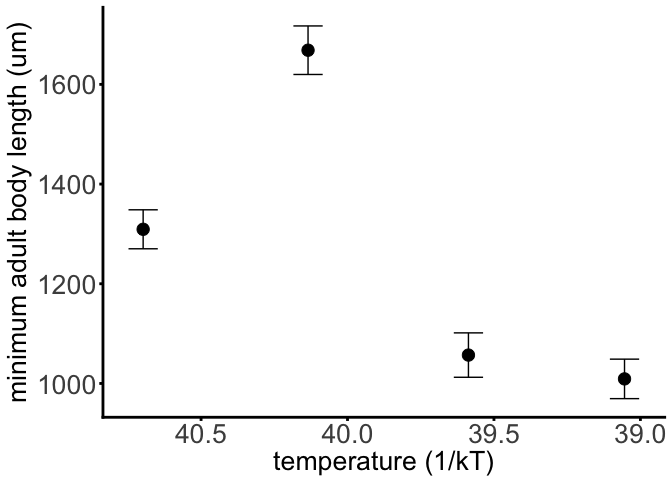

#### Maximum adult body size

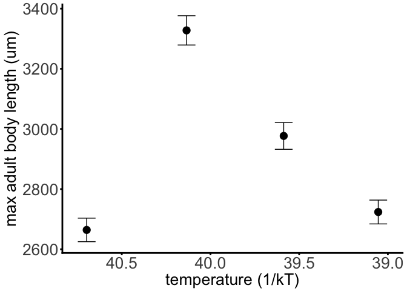

#### Mean adult body size

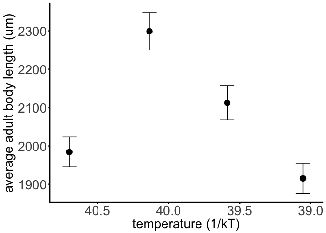

#### Next step: bring in the fecundity data to merge with the size data

```r
lengths_clean <- lengths_all_adult %>%
    mutate(unique_id = str_replace(unique_id, "2N1.2", "N")) %>%
    mutate(unique_id = str_replace(unique_id, "2N1.3", "N")) %>%
    mutate(unique_id = str_replace(unique_id, "2N1.4", "N")) %>%
    mutate(unique_id = str_replace(unique_id, "2N1.8", "N")) %>%
    mutate(unique_id = str_replace(unique_id, "2N1.5", "N")) %>%
    mutate(unique_id = str_replace(unique_id, "2N1.1", "N")) %>%
    separate(unique_id, into = c("letter", "temp"), remove = FALSE) %>%
    mutate(life_stage = ifelse(life_stage == "1", "clutch_1", life_stage)) %>%
    mutate(life_stage = ifelse(life_stage == "2", "clutch_2", life_stage)) %>%
    mutate(life_stage = ifelse(life_stage == "3", "clutch_3", life_stage)) %>%
    mutate(life_stage = ifelse(life_stage == "4", "clutch_4", life_stage)) %>%
    rename(clutch_number = life_stage)


data_raw <- read_csv("/Users/Joey/Documents/Daph-TSR/data-raw/DAPH-TSR-clutches.csv")
v2_babies <- data_raw %>%
    filter(grepl("V2", ID)) %>%
    separate(ID, into = c("V", "letter"), sep = 2) %>%
    unite(unique_id, letter, temperature, sep = "_")


data_raw %>%
    filter(str_detect(ID, "N")) %>%
    arrange(temperature, clutch_number)### come back to filling out the clutch number business here, it's clearly not totally complete!
```

```
## # A tibble: 14 × 6
##       ID temperature clutch_number individuals   clutch_date   sample_date
##    <chr>       <int>         <chr>       <int>         <chr>         <chr>
## 1    V2N          16      clutch_1           2  July 19 2016 August 5 2016
## 2    V2N          16      clutch_2           4  July 23 2016 August 5 2016
## 3    V2N          16      clutch_3           0 August 1 2016 August 8 2016
## 4    V2N          16      clutch_4           9 August 4 2016 August 5 2016
## 5    V2N          20      clutch_1          14  July 13 2016  July 18 2016
## 6    V2N          20      clutch_1          17  July 16 2016  July 18 2016
## 7    V2N          20      clutch_2          15  July 19 2016 August 5 2016
## 8    V2N          20      clutch_3           5  July 21 2016 August 5 2016
## 9    V2N          24      clutch_1           9  July 17 2016          <NA>
## 10   V2N          24      clutch_2          18  July 18 2016          <NA>
## 11   V2N          24      clutch_3           5  July 20 2016 August 5 2016
## 12   V2N          24      clutch_3          NA  July 20 2016          <NA>
## 13   V2N          24      clutch_4           0  July 22 2016 August 5 2016
## 14   V2N          24      clutch_4          NA  July 22 2016          <NA>
```

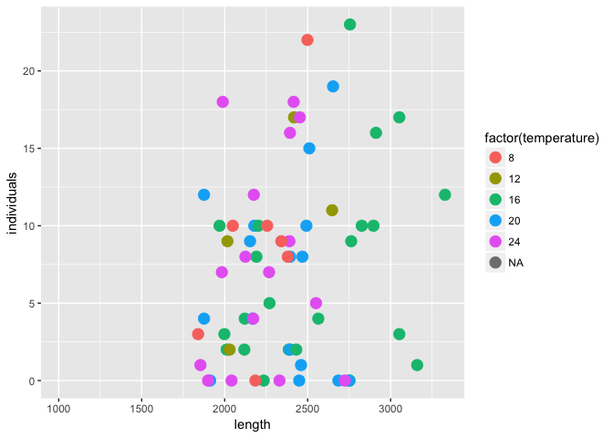

```r
all <- left_join(lengths_clean, v2_babies, by = c("unique_id", "clutch_number"))

ggplot(data = all, aes(x = length, y = individuals, color = factor(temperature))) + geom_point(size = 4)
```

For a given temperature, plot size vs. number of individuals

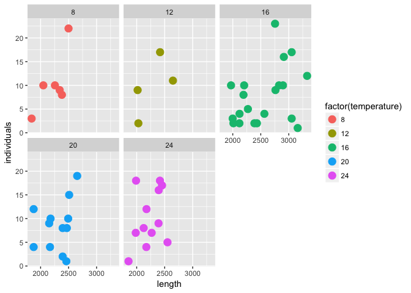

```r
all %>%
filter(individuals != 0) %>%
ggplot(data = ., aes(x = length, y = individuals, color = factor(temperature))) + geom_point(size = 4) + facet_wrap( ~ temperature)
```

How do we answer the question: is being smaller at a given temperature maximizing your fitness?

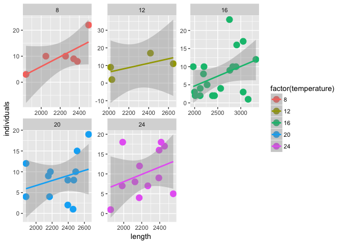

```r
all %>%
    filter(individuals != 0) %>%
    # filter(temperature == 24) %>%
ggplot(data = ., aes(x = length, y = individuals, color = factor(temperature))) + geom_point(size = 4) + geom_smooth(method = "lm") +
    facet_wrap( ~ temperature, scales = "free")
```

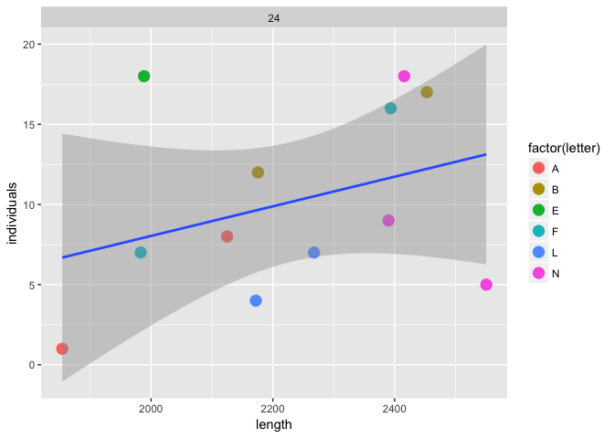

```r
all %>%
    filter(temperature == 24) %>%
    filter(individuals != 0) %>%
ggplot(data = ., aes(x = length, y = individuals)) + geom_point(aes(color = factor(letter)), size = 4) + geom_smooth(method = "lm") +
    facet_wrap( ~ temperature)
```

Ok so what I think we are seeing is that on a per individual clutch basis, there is still a positive relationship between body size and number of individuals per clutch…which I guess is not surprising…but maybe a more accurate measure of fitness is the number of offspring per unit time??? Maybe I should have looked at total lifetime reproductive output, not the number of offspring per clutch? It’s clear that the warmer invidividuals pump through more clutches per unit time. Maybe I should look at whether within a temperature, you get through more clutches if you are smaller?

Maybe I should take the time to first reproduction and average clutch size and somehow plot that versus size at temperature?

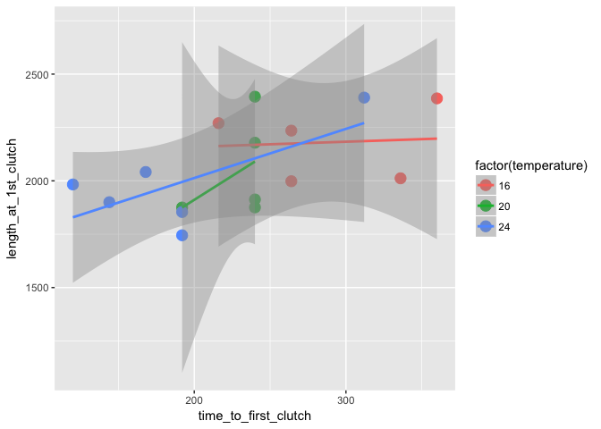

```r
data3_select <- data3 %>%
    select(id, temperature, time_to_first_clutch, length_at_1st_clutch, length_at_2nd_clutch_um) %>%
    mutate(id = str_replace(id, "2N1.2", "N")) %>%
    mutate(id = str_replace(id, "2N1.3", "N")) %>%
    mutate(id = str_replace(id, "2N1.1", "N")) %>%
    mutate(id = str_replace(id, "2N1.4", "N")) %>%
    mutate(id = str_replace(id, "2N1.5", "N"))




data3_select %>%
    filter(time_to_first_clutch != 1176) %>%
    filter(temperature > 13) %>%
    ggplot(data = ., aes(x = time_to_first_clutch, y = length_at_1st_clutch, color = factor(temperature), label = id)) + geom_point(size = 4) + geom_smooth(method = "lm")
```

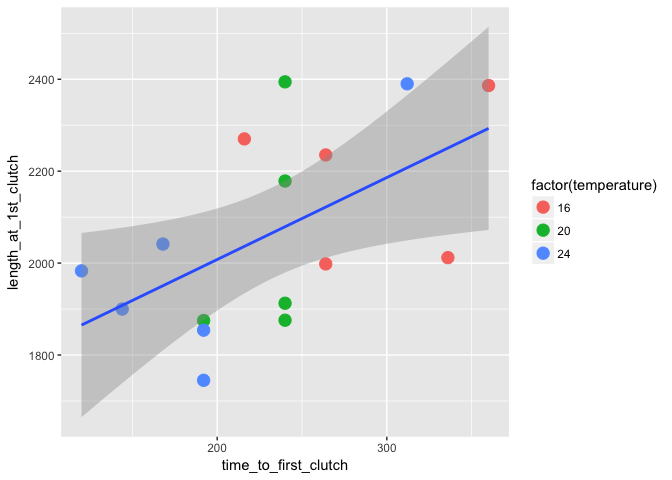

```r
data3_select %>%
    filter(time_to_first_clutch != 1176) %>%
    filter(temperature > 13) %>%
    ggplot(data = ., aes(x = time_to_first_clutch, y = length_at_1st_clutch)) + geom_point(aes(color = factor(temperature)), size = 4) + geom_smooth(method = "lm")
```

```r
tidy(lm(length_at_1st_clutch ~ time_to_first_clutch, data = data3_select), conf.int = TRUE)
```

```
##                   term     estimate  std.error statistic      p.value
## 1          (Intercept) 1877.3353429 82.8180744 22.668184 9.579253e-17
## 2 time_to_first_clutch    0.5647173  0.2083568  2.710338 1.277848e-02
##       conf.low    conf.high
## 1 1705.5811688 2049.0895169
## 2    0.1326119    0.9968228
```

```r
summary(lm(length_at_1st_clutch ~ time_to_first_clutch, data = data3_select))
```

```
##
## Call:
## lm(formula = length_at_1st_clutch ~ time_to_first_clutch, data = data3_select)
##
## Residuals:
##     Min      1Q  Median      3Q     Max
## -430.49 -133.07  -54.05  176.50  381.44
##
## Coefficients:
##                       Estimate Std. Error t value Pr(>|t|)
## (Intercept)          1877.3353    82.8181   22.67   <2e-16 ***
## time_to_first_clutch    0.5647     0.2084    2.71   0.0128 *
## ---
## Signif. codes:  0 '***' 0.001 '**' 0.01 '*' 0.05 '.' 0.1 ' ' 1
##
## Residual standard error: 221.5 on 22 degrees of freedom
##   (14 observations deleted due to missingness)
## Multiple R-squared:  0.2503, Adjusted R-squared:  0.2162
## F-statistic: 7.346 on 1 and 22 DF,  p-value: 0.01278
```